# 統計学2

Rマークダウンの使い方

矢内 勇生

2018-04-19（改訂：2019-04-19, 2019-06-03, 2020-08-18, 2021-04-16, 2021-04-21, 2022-03-20, 2022-03-24）

まず、マークダウン全体のオプション（グローバルチャンクオプション）を指定する。 PDFに出力する（LaTeX 使う）場合は、グラフィックデバイスに cairo を利用するが、HTML の場合には cairo を使いたくないので、`knitr::is_latex_output()` を利用して場合分けする。 以下のコードチャンクは、オプションに `include = FALSE` がついているので、出力されたPDFやHTML では非表示になる。 このチャンク（グローバルオプション）は**常にYAMLヘッダのすぐ下に書く**べきである。

# 準備

**tidyverse** パッケージを読み込む。パッケージのインストールは一度すれば済むが、`library()` を使ったパッケージの読み込みは、Rを起動するたびに行う必要がある。

```r
library(tidyverse)
```

```r
## 図のなかで日本語を使えるようにする
## フォントの設定はお好みで
## （Unix/Linux ではIPAexフォントのインストールが必要かも）
library(fontregisterer)
if (.Platform$OS.type == "windows") { # Windows
  my_font <- "Yu Gothic"
} else if (capabilities("aqua")) { # macOS
  my_font <- "Hiragino Sans"
} else { # Unix/Linux
  my_font <- "IPAexGothic"
}
theme_set(theme_gray(base_size = 9,
                     base_family = my_font))
```

# Rマークダウンの書き方・使い方

マークダウンファイル ([r-markdown.Rmd](https://drive.google.com/file/d/10WU4x2hmgs_SPpNNZR7xQiezm12DsCxT/view?usp=sharing)) とそのファイルを元に生成されたPDFファイル （PDFを開いているならそのファイル）([r-markdown.pdf](https://drive.google.com/file/d/10Y5zqNk3M6ZuvCClJvaL7fX7jFOtGD_r/view?usp=sharing))と htmlファイル（インターネットブラウザで読んでいるならそのファイル）（r-markdown.html) を見比べながら、RStudioでRマークダウンファイルを扱えるようにするのが今日の目標である。

このマークダウンをそのまま使うためには、担当教員が作ったスタイルシート（my-markdown.css）をプロジェクトのフォルダに保存する必要がある。 スタイル（表示されるページの見た目）をカスタマイズしたいときは、このファイルを変更すればよい。デフォルトのスタイルのままで良いとき（あまり良くないと思うが）は、ヘッダの’css’オプションの指定をやめる（このRmdファイル [htmlではない] のYAMLヘッダ部分にある `css: my-markdown.css` の行を削除する）。

この資料と同じ画像を表示するためには、画像ファイルも同じフォルダに保存する必要がある。自分でもっている画像（写真）に置き換えて試してほしい。

## マークダウン記法を利用した文章の書き方

文章は、いつもどおり書けばよい。 文章の一部をイタリック（斜字体）にしたいときは、イタリックにしたい部分を * または _ で挟むと、*this is italic* あるいは *this is also italic* となる（日本語は斜字体にしない）。 太字は、**（*を2つ） または __（_ を2つ）で挟むと、**ここが太字** または **ここも太字** となる。 太字のイタリックは、*** （*を3つ）または ___（_を3つ）で挟むと、*here is bold italic* または *here is also bold italic* となる。

改行するときは、文章の間を1行以上空ける。

箇条書きは、* または _ を利用し、

- 項目1
- 項目2
  - 項目2-1
  - 項目2-2

あるいは、

- 項目1
  - 項目1-1
  - 項目1-2
- 項目2

のようにできる。* や - の後には半角スペースを挿入する。箇条書きを入れ子にするとき、字下げは Tab で行う

番号付きの箇条書きは、数字で作れる。

1. First item
2. Second item
   1. What?
   2. How?
3. Third item

のようにする。入力する際にすべて「1.」にしても、自動的に1, 2, 3, … とうい番号が割り当てられる。全部1にしておくと、後から項目の並べ替えができるので楽である。（1でなくても並べ替えられるが、数字の意味が不明になる。）

ヘディング (heading) は、“#” （ハッシュ記号） で作れる。 論文・レポートを書くときは、ヘディングを利用して文章を構造化する。 # の数が少ないほど、上位のヘディングになる。**Rコードのコメントと同じ記号だが、その役割はまったく異なるので誤解しなように注意されたい**。

例を以下に示す。

# ハッシュ1つのヘディング

## ハッシュ2つのヘディング

### ハッシュ3つのヘディング

#### ハッシュ4つのヘディング

論文・レポートでは、以下のようにヘディングを使い分ける。

- #: 節（セクション, section）
- ##: 小節 (subsection)
- ###: 小節以下の見出し (subsubsection)
- ####: （あまり使わない）

また、リンクを貼ることもできる：[矢内のウェブサイト](https://yukiyanai.github.io/jp/)。

画像も貼れる：

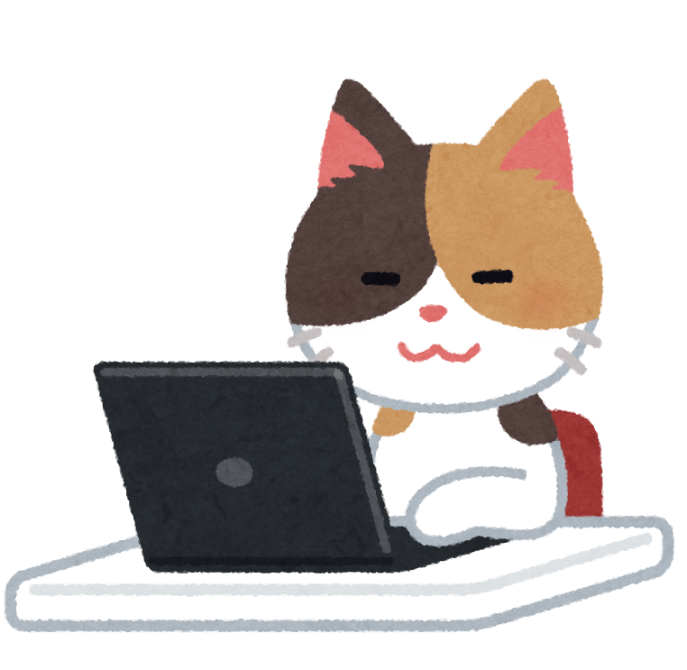

（出典：[いらすとや](https://www.irasutoya.com/2018/10/blog-post_67.html)）

画像へのパス (path) が通っていないと表示されないので注意。

HTMLに出力する場合は、HTMLを直接書くこともできる（PDFに出力する場合はうまくいかない）。

- リンクを貼る：[矢内のウェブサイト](https://yukiyanai.github.io/jp/)
- 画像を貼る：

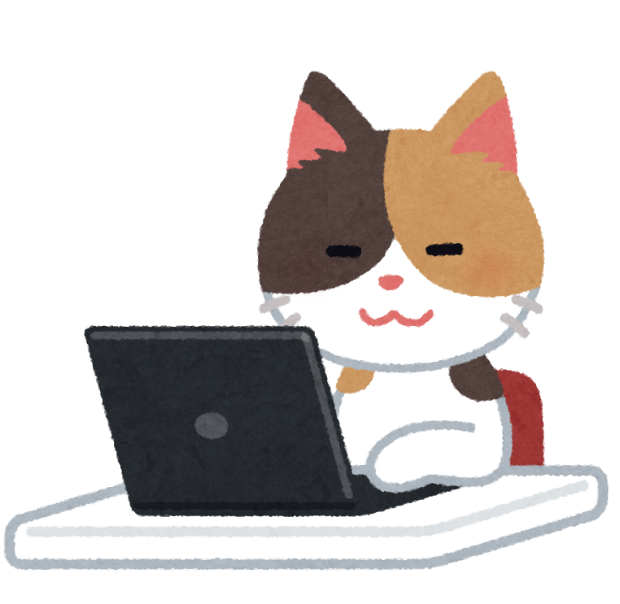

### $\ast$ 数式の書き方

LaTeX と同じように数式を書くこともできる。 文章中と同じ行に数式を書きたいときは、`$`で挟む。 たとえば、$\bar{x} = \sum_{i=1}^n x_i / n$ と、する。

数式を独立したブロックとして書きたいときは、`$$`で挟み、
$$\sigma^2 = \frac{\sum_{i=1}^n (x_i - \mu)^2}{n}$$
のようにする。

## コードチャンクの書き方

Rのコードは、コードチャンクと呼ばれる部分に書き込む。 コードチャンクは、たとえば以下のように書ける。

```r
a <- 1:10
b <- -1:-10
```

Rコードチャンクの始めには、3つの「`」の後に{r}をつける。 rとスペースの後（{}の中）には、チャンクの名前を付ける。 好きな名前を付けてよいが、**他のチャンクとまったく同じ名前は付けられない**（つまり、各チャンクが異なる名前をもつ必要がある）。 チャンクの終わりには3つの「`」を書く。 RStudioで開いたRマークダウンファイル内でコードチャンクを作るには、次のショートカットキーを使った方がよい。

- macOS: `cmmandd` + `option` + `I` または `control` + `option` + `I`
- Windows: `Ctrl` + `Alt` + `I`

文章中にRコードを書きたいときは `mean(x)` のように、Rのコマンドを`の間に書く。 関数を実行（評価, evaluate）した後の結果を文章中に入れたいときは、「$a$ の平均値は ` r mean(a) ` です」のように “r” を入れて書くと、「$a$ の平均値は5.5 です」となる。つまり、`mean(a)` というコマンド をRが実行し、その結果を文章の中に入れてくれる。この方法を使えば、文章と別にRのコマンドを実行しなくても、Rの実行結果を表示することができる。

図を含めた文章も作れる。チャンクオプション `fig.cap` で図のキャプションが指定できる。

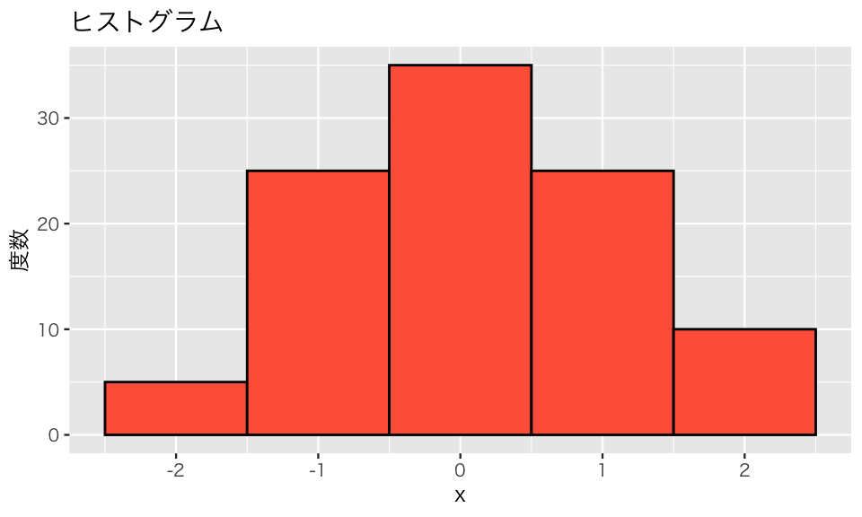

トマト色のヒストグラム

```r
p <- tibble(x = rnorm(100, mean = 0, sd = 1)) %>%
  ggplot(aes(x = x)) +
  geom_histogram(binwidth = 1, color = "black", fill = "tomato") +
  labs(y = "度数", title = "ヒストグラム")
plot(p)
```

何もオプションを指定しない状態では、チャンクは1行ずつ評価され、結果も順番に次々出力される。 たとえば、

```r
sd(a)
```

```
## [1] 3.02765
```

```r
var(a)
```

```
## [1] 9.166667
```

チャンクの最後まで評価してからまとめて結果表示したいときは、チャンクオプション**results** を’hold’にする。 オプションは、チャンク名の後に「,（comma）」を打ち、その後に書く。 例えば、`{r example-option, results = 'hold'}` とチャンクの冒頭に書くと、

```r
sd(a)
var(a)
```

```
## [1] 3.02765
## [1] 9.166667
```

となる。

チャンクオプションについてより詳しくは [ココ](http://d.hatena.ne.jp/teramonagi/20130615/1371303616) などを参照されたい。

また、Rマークダウン全般（特に、RStudioを使う場合）については、[ココ](https://kazutan.github.io/JSSP2018_spring/intro_rstudio.html) を参照。

Rマークダウンのチートシート（[PDFファイル](https://github.com/rstudio/cheatsheets/blob/master/translations/japanese/Rmarkdown-cheatsheet-2.0_ja.pdf)）

[授業の内容に戻る](https://yukiyanai.github.io/stat2/r-markdown.html)